# PROJET R et Dataviz

Analyse des loyers à Dakar

BOUIKIOUCH Lahcen - MOURI Imad - BENALI Elies - SABER Anas DaMS 3 - TD1

2025-11-10

## Description du jeu de données

Ce jeu de données porte sur les logements Dakarois ainsi que leurs locations. Ce jeu contient 29 variables et une quarantaine d’individus correspondant à des logements dans la capitale du Sénégal. Pour chaque individu, on a une liste de variable décrivant le logement tels que: le loyer, la surface du terrain, la distance avec le bord de mer, le centre ville, le nombre de pièces, etc… L’objectif premier de cette analyse est donc de comprendre quels sont les facteurs qui rentrent en compte dans le prix du loyer.

## I - Distribution des loyers

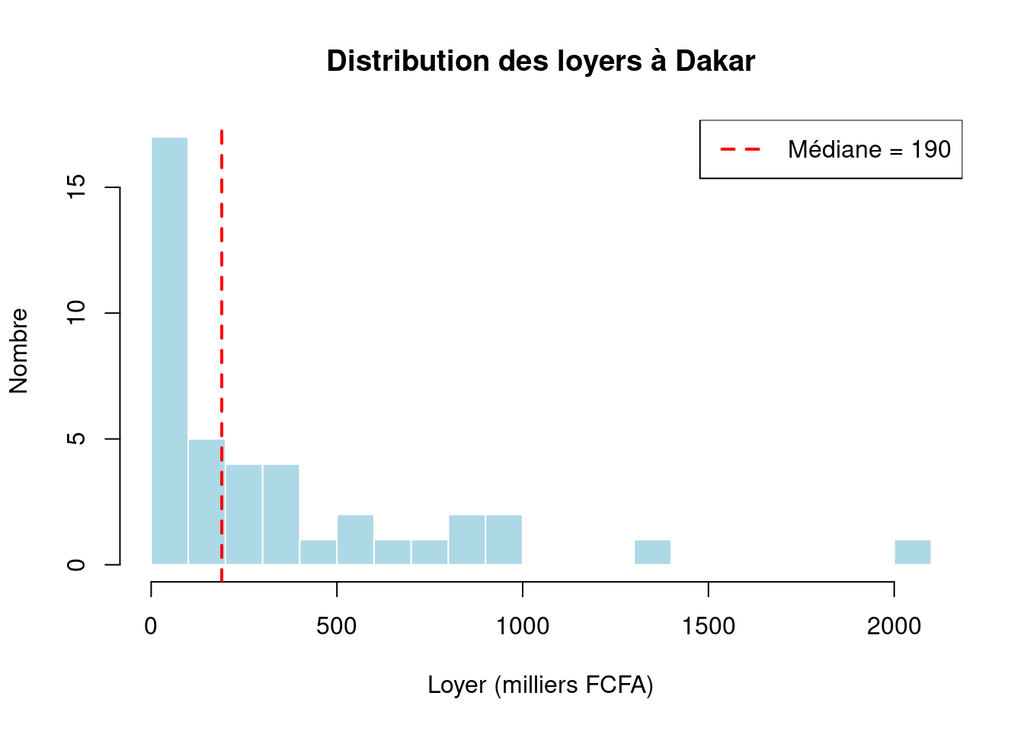

**Analyse :** Pour démarrer cette analyse, nous commençons par une distribution des loyers pour voir comment ils se situent en nombre par rapport au prix du loyer. Comme le montre ce diagramme à barres, la distribution des loyers présente une disparité très importante, notamment vers le côté droit de la figure. Cela signifie que la grande majorité des logements se situent dans une tranche de prix relativement modeste (entre 50 et 400 milliers FCFA), tandis qu’une minorité de propriétés atteignent des loyers très élevés (jusqu’à 2100 milliers FCFA !). Cette distribution met en avant un marché immobilier assez fragmenté par la présence d’une majorité de logements populaires et d’autres de très haut standing. La médiane, inférieure à la moyenne, confirme une fois encore la très grande inégalité entre le nombre d’habitations au loyer assez faible et ceux au loyer exorbitant.

## II - Loyer selon la surface habitable

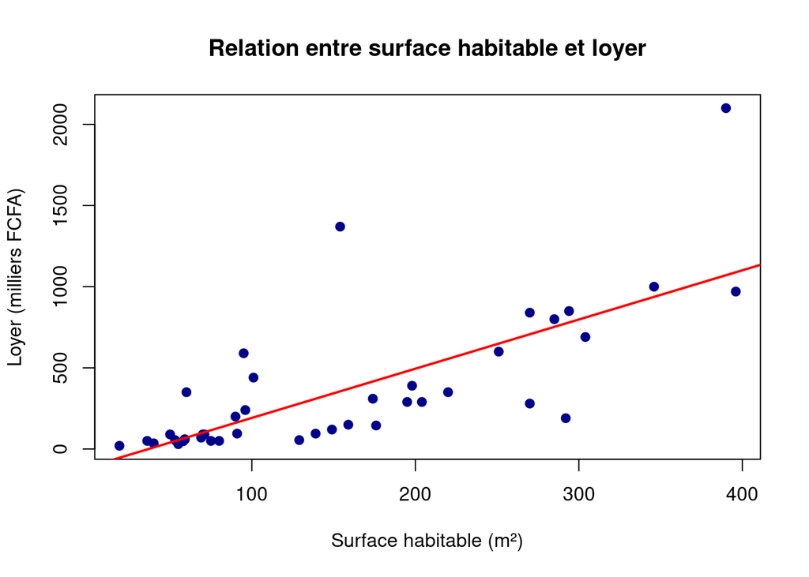

**Analyse :** Après avoir eu une vue d’ensemble sur la distribution des loyers, nous pouvons désormais nous tourner vers le loyer en fonction de la surface habitable via un nuage de point. A première vue on peut tirer une conclusion simple: plus un logement est grand, plus son loyer tend à aussi être élevé. Cependant, la dispersion importante des points autour de la ligne de régression nous montre que la surface n’est pas le seul facteur du prix. On voit assez aisément que pour une même surface (100m² par exemple), les loyers peuvent différer de plusieurs centaines de milliers de FCFA. Cette différence laisse donc entendre que la surface habitable habitable est un facteur important pour le prix du loyer mais que d’autres facteurs entrent en compte pour le faire varier ainsi…

## III - Loyer selon le type de bien

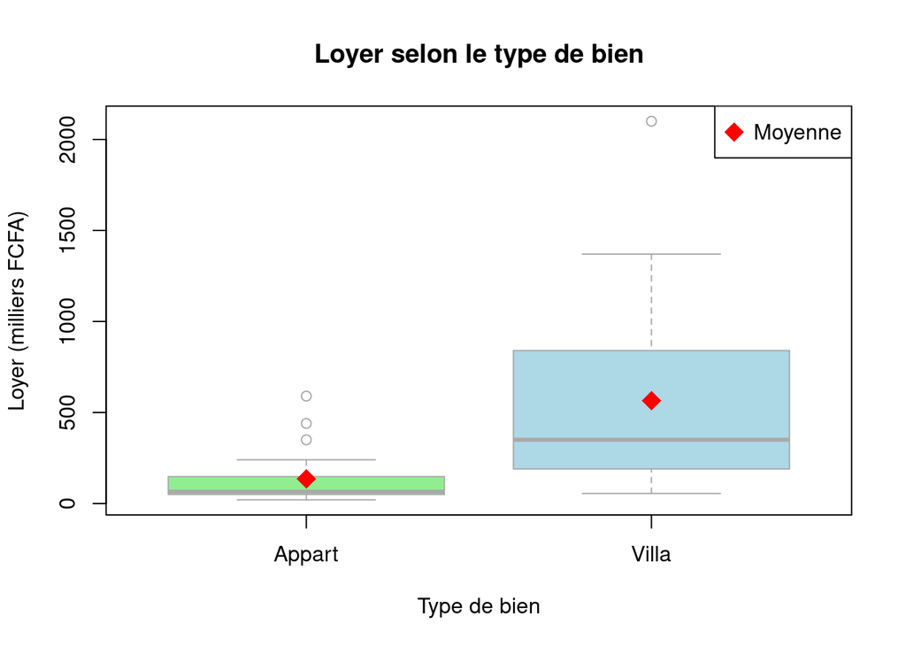

**Analyse :** Pour la suite et le reste de cette analyse nous allons nous aider des boites à moustaches pour nous aider à comprendre le reste des facteurs déterminant le loyer. Nous avons ici une boite à moustache mettant en avant le loyer selon le type de bien. Et on le voit tout de suite, ce dernier est très impactant sur le montant du loyer. Les villas présentent une médiane (barre grise dans la boite bleue) et une moyenne (point rouge) de loyer nettement supérieures à celles des appartements. Ce qui s’explique par plusieurs éléments, d’une part les villas offrent des surfaces plus importantes, elles disposent d’espaces extérieurs tel que des jardins, et sont souvent situées dans des quartiers résidentiels plus “aisés”. On peut aussi noter une différence de loyer conséquente entre les villas, comme l’illustre l’étendue plus large de leur boîte à moustaches entre les quartiles. Les appartements montrent quant à eux une distribution plus rapproché avec des loyers plus bas.

## IV - Loyer selon le standing

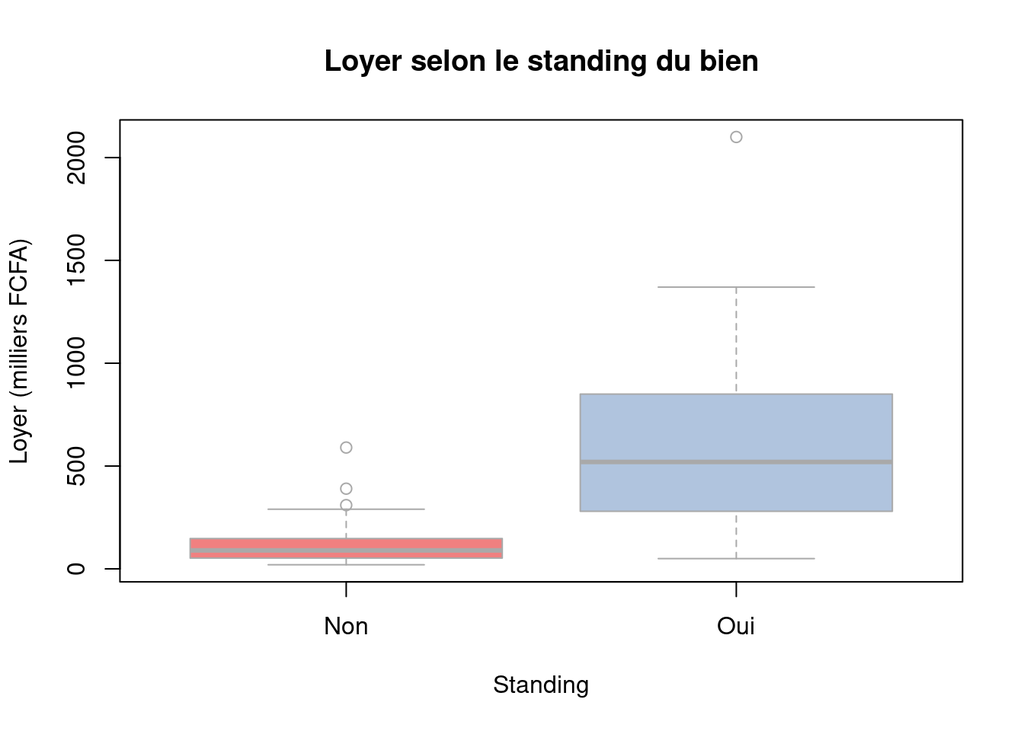

**Analyse :** Cette boite à moustaches concernant cette fois si standing du bien souligne cette fois aussi qu’il s’agit d’un des facteurs importants dans la détermination du loyer. Les habitations classées comme “haut standing” (Standing = Oui) possèdent un loyer médian et moyen largement supérieur aux biens standards (Standing = Non). Les biens de haut standing sont généralement caractérisés par de meilleurs matériaux, des équipements modernes, et souvent une architecture soignée ce qui explique le prix aussi élevé de ces biens. Contrairement aux biens standards qui se limitent très certainement aux essentiels pour vivre. L’écart important entre les deux catégories démontre donc que le standing est aussi un facteur majeur dans le prix du loyer.

## V - Loyer selon le standing du quartier

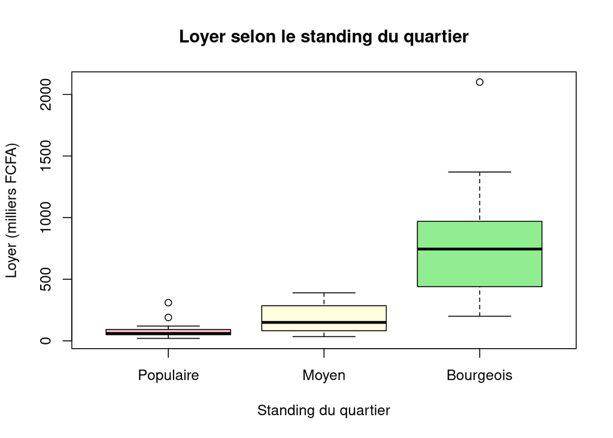

**Analyse :** Nous observons assez facilement aussi que le standing du quartier est aussi un acteur majeur du prix des loyers, qui appuie le fait que la valeur des biens est différente selon la localisation. Pour faire simple : les quartiers populaires présentent des loyers médians très faibles, les quartiers moyens se situent dans une portion intermédiaire, tandis que les quartiers bourgeois présentent les loyers les plus élevés. Ce “classement” révèle non seulement la qualité de vie, mais aussi l’accès à des services et infrastructures de meilleure qualité ce qui expliquent l’augmentation du loyer en parallèle du standing. Les quartiers bourgeois bénéficient également d’un effet de prestige social qui justifie des prix plus élevés. A noter de même que précédemment, une disparité est présente entre les loyers dans le standing bourgeois ce qui montre que les écarts sont aussi présents et importants entre ultra-riches.

## VI - Loyer selon la distance au centre-ville

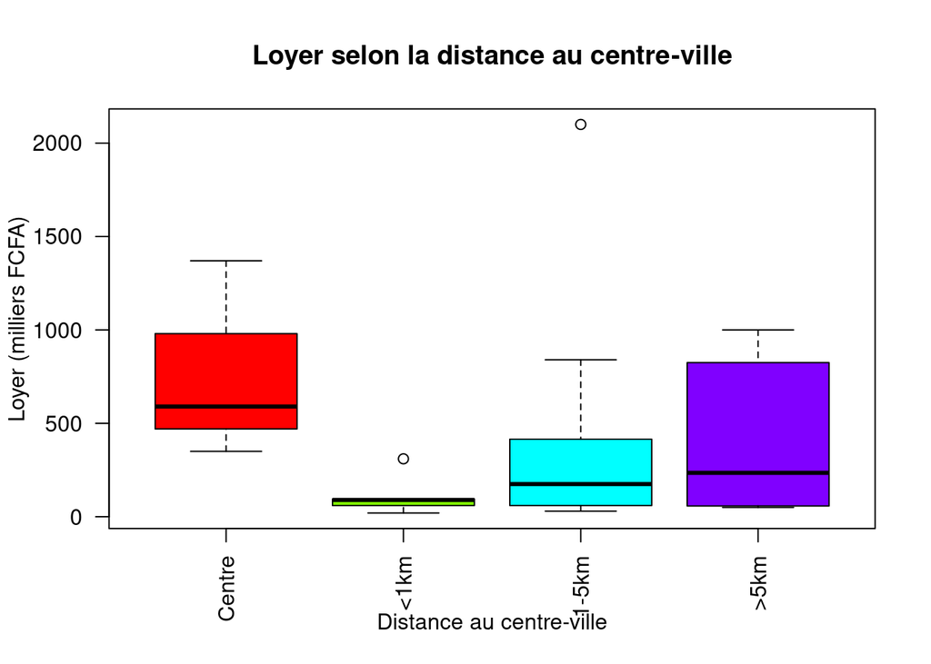

## VII - Loyer selon l’état du bien

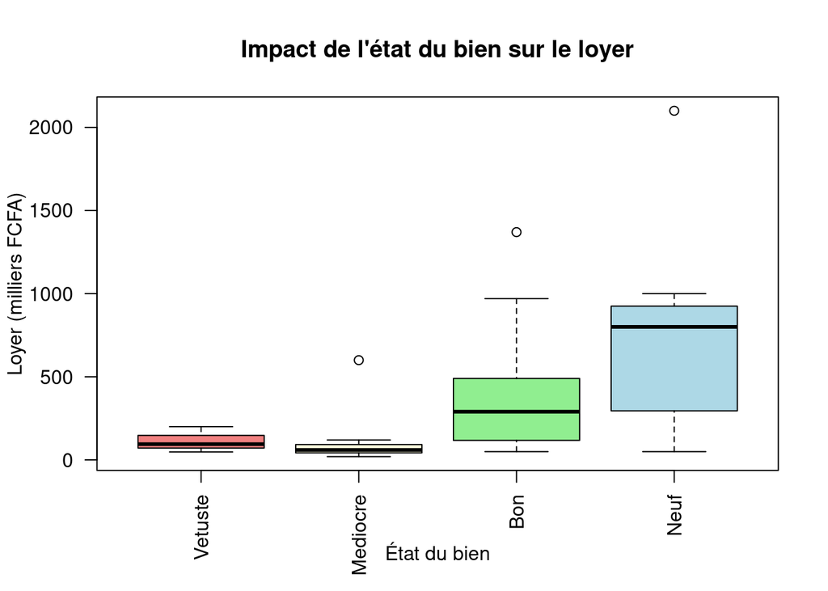